# fasterWilcox presentation

Lorenzo_Benatti

2024-03-01

# fasterWilcox

FasterWilcox is a function that speeds up R’s wilcox.test() It uses Rcpp

## example use

```r
v1<- c(45, 33, 35, 39, 42)
v2<- c(34, 36, 41, 43, 44)


fasterWilcox_v3(v1, v2, alternative = "two.sided", paired = F, verbose = F)$p.value
```

```
## [1] 0.8345316
```

```r
fasterWilcox_v3(v1, v2, alternative = "two.sided", paired = T, verbose = F)$p.value
```

```
## [1] 0.5896386
```

## Speed comparison

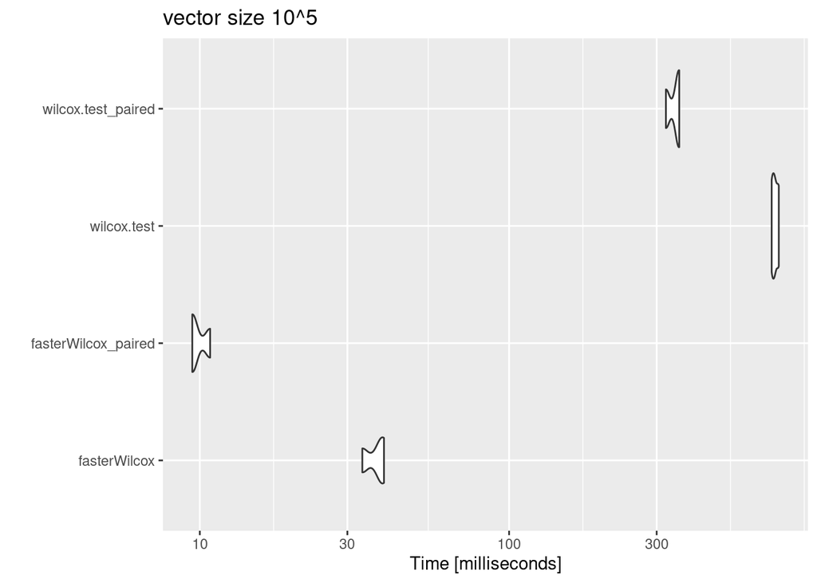

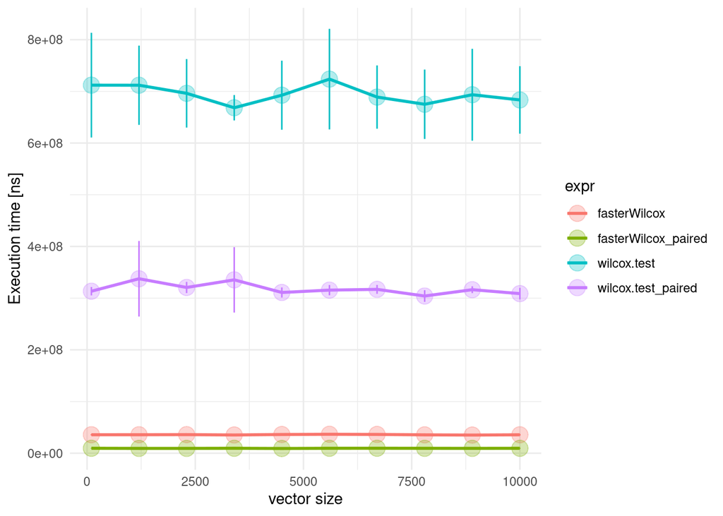

## Accuracy comparison

Here’s a boxplot and a density plot of the difference between the p-values given by wilcox.test() and fasterWilcox()

The maximum difference is less than +-5e-16

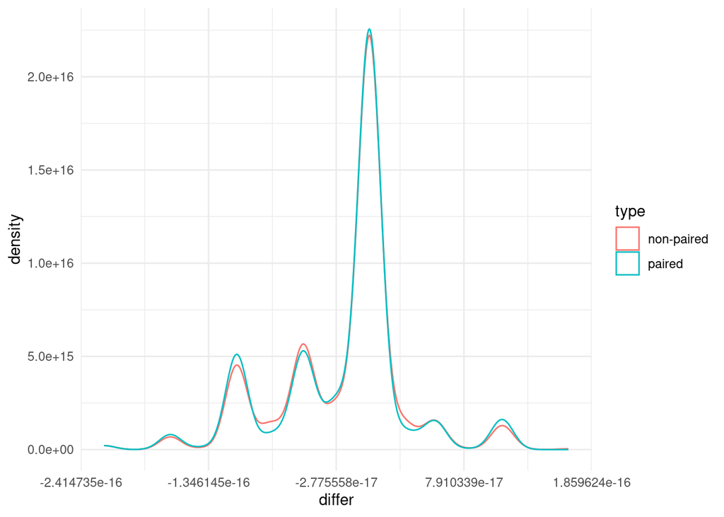

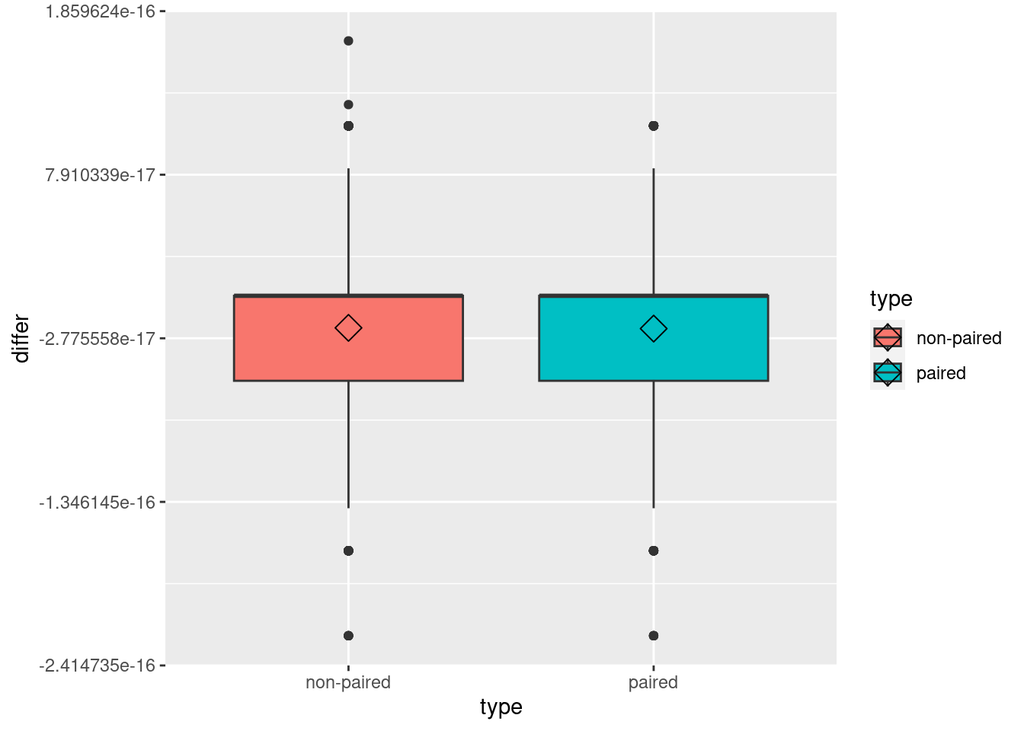

# Sparse matrices

Let’s consider two methods to perform Wilcox test on a row of a sparse matrix:

1. (“OLD”)copying the entire row (along with all the zeroes), selecting two subvectors and applying the regular test
2. (“NEW”)copying the entire row (without the zeroes), selecting two subvectors and applying a slightly modified version of the test (to account for the missing zeroes)

method 1 is coded in the function sparse_fasterWilcox_old() (inside Wilcoxon_ststistics.cpp)

method 2 is coded in sparse_fasterWilcox_new() (inside sparse_fasterWilcox_v3.cpp -> It’s just a call to the methods implemented in sparse.h)

## Example use

```r
# creo una sparse matrix random:
set.seed(124)
sparsity = 0.5 #%

numrow = 10
numcol = 10

non_zero_elem = (sparsity)*(numrow*numcol)

# row indices
i <- sample(numrow,non_zero_elem, replace = T)
# column indices
j <- sample(numcol,non_zero_elem, replace = T)
# numbers
x <- rpois(non_zero_elem,10)


sp_matrix <- sparseMatrix(i=i,j=j,x=x)
sp_matrix
```

```
## 10 x 10 sparse Matrix of class "dgCMatrix"
##
##  [1,] 36 14  9  6 .  .  .  .  6  .
##  [2,]  8  8  .  6 . 13  .  . 17 13
##  [3,]  .  .  . 15 . 11  .  .  . 11
##  [4,]  . 11  .  . . 18  .  .  9  .
##  [5,]  .  .  .  . 6  . 16  .  .  .
##  [6,] 11 10  .  . 7  .  7 16 13  .
##  [7,]  .  . 12 13 3  .  .  . 11 11
##  [8,]  .  . 23  . 9  .  .  .  . 12
##  [9,] 12  .  . 10 . 10  . 27  .  .
## [10,] 24  .  .  8 .  .  .  .  5 23
```

```r
sparse_fasterWilcox_new(sp_matrix, rowIndex = 1:numrow, col_id = 1:(numcol/2), ref_col_id = ((numcol/2)+1):numcol, paired = T  )
```

```
##      p.value sign
## 1  0.1814492    1
## 2  0.3613104    0
## 3  1.0000000    0
## 4  0.7892680    0
## 5  1.0000000    0
## 6  0.7874065    0
## 7  0.7892680    1
## 8  1.0000000    1
## 9  1.0000000    0
## 10 0.7892680    1
```

## Important notes:

In method 2, the function sparseWilcox() (inside sparse.h) uses a slightly modified version of extractCol(), that, instead of instantiating a single std::vector<std::vector > populates two. One is for the numbers and the other for their corresponding column index inside the sparse matrix.

This second 2dVector of indices is used only for the paired test and results in a

MEMORY USAGE >= 2*(dim(selected_submatrix))

```cpp
  Rcpp::DataFrame sparseWilcox (Rcpp::NumericVector rowIndex,
                                           Rcpp::NumericVector col_id,
                                           Rcpp::NumericVector ref_col_id,
                                           bool paired,
                                           std::string alternative = "two.sided",
                                           bool verbose = 0){
    // some variables are initialized (not shown)


    // what happens in method 1(inside wilcoxon_statistics.cpp )
    // std::vector<std::vector<double>>  tmp1s = extractCol(col_id);
    // std::vector<std::vector<double>> tmp2s = extractCol(ref_col_id);


    // method2
    std::vector<std::vector<double>>  tmp1s(Dim[0]);
    std::vector<std::vector<double>>  tmp1s_idx(Dim[0]);
    extractCol_and_col_idx(tmp1s, tmp1s_idx, col_id);

    std::vector<std::vector<double>>  tmp2s(Dim[0]);
    std::vector<std::vector<double>>  tmp2s_idx(Dim[0]);
    extractCol_and_col_idx(tmp2s, tmp2s_idx, ref_col_id);


    for (int rr = 0; rr < rowIndex.length(); rr++) {

      if(!paired){
        //call non-paired function
      }else{
        //call paired function
      }

    }
```

## Execution time over sparsity

matrix size 100x1000

graphs changes with the matrix form factor

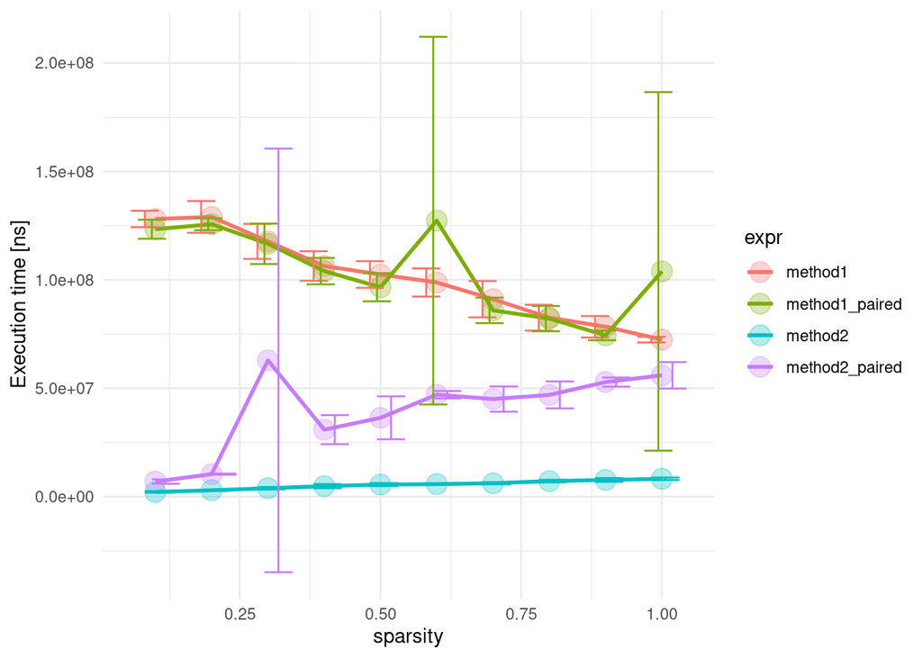

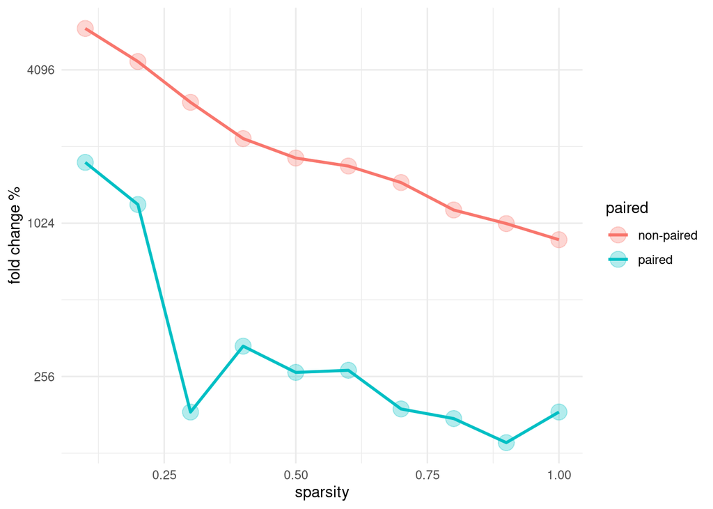

## Accuracy comparison

Here’s a boxplot and a density plot of the difference between the p-values given by wilcox.test() and sparse_faster_wilcox_new()

The maximum difference is less than +-5e-16

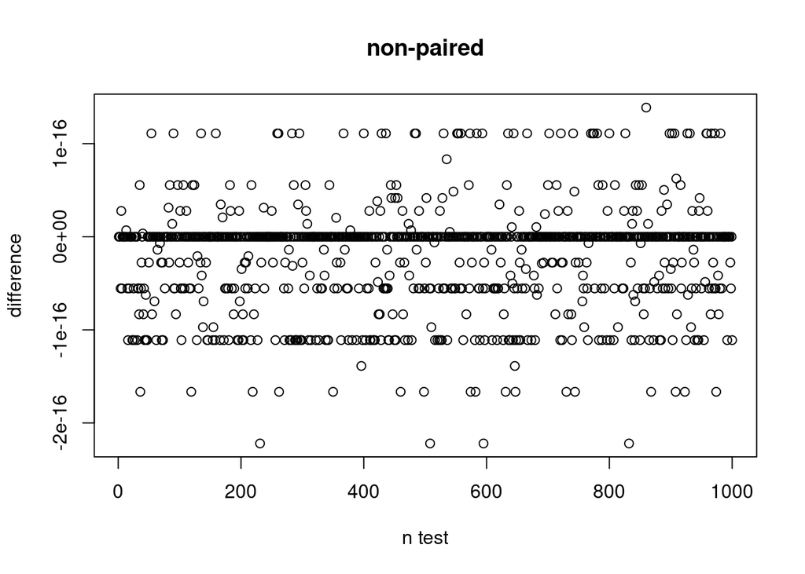

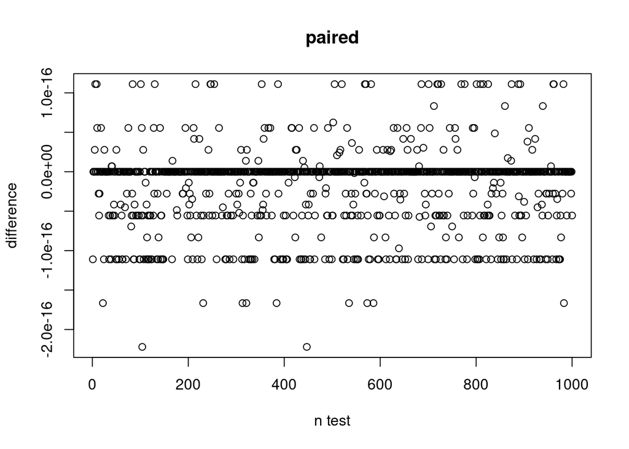

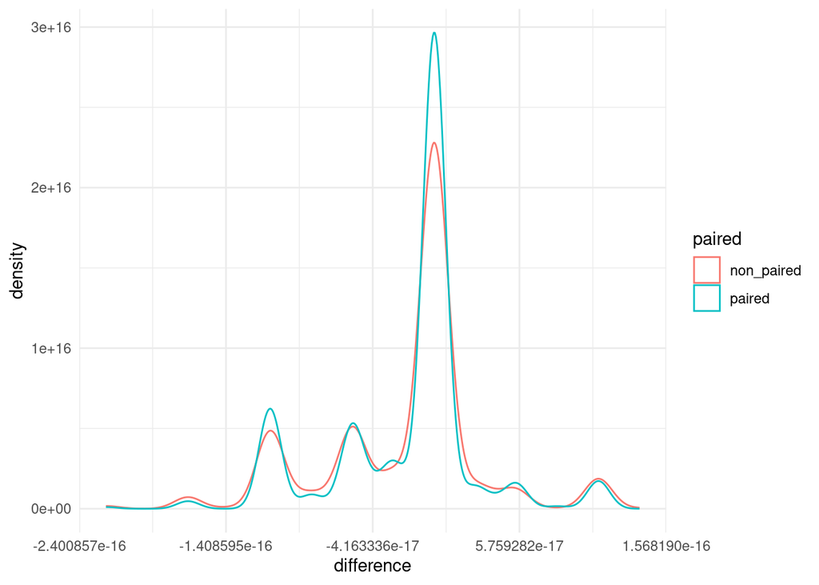

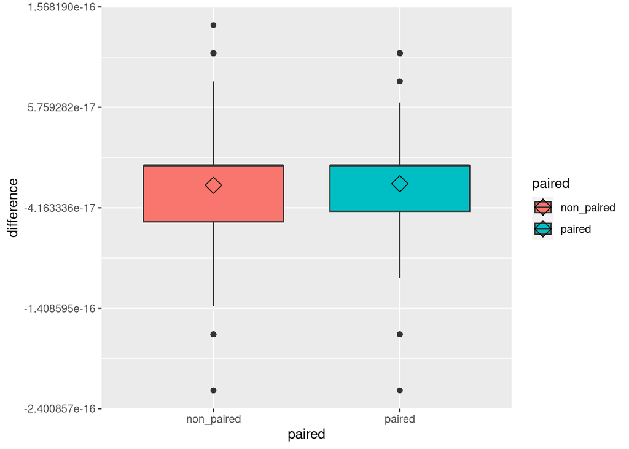

```
## [1] 0
```